# The Structure Function

David Asare Kumi

11/1/2019

## Str Function

- str compactly display the internal structure of an R object.
- A diagnostic function and an alternative to “summary”.
- It is especially well suited to compactly display the (abbreviated) contents of (possibly nested) lists.
- Roughly one line per basic object.

## What’s in this object

```r
str(str)
```

```
function (object, ...)
```

```r
str(lm)
```

```
function (formula, data, subset, weights, na.action, method = "qr",
    model = TRUE, x = FALSE, y = FALSE, qr = TRUE, singular.ok = TRUE,
    contrasts = NULL, offset, ...)
```

```r
x <-rnorm(100,2,4)
summary(x)
```

```
   Min. 1st Qu.  Median    Mean 3rd Qu.    Max.
-8.1386 -1.7940  1.0446  0.7511  3.6730  9.7587
```

```r
str(x)
```

```
 num [1:100] 5.7 -1.25 -4.75 5.55 -4.4 ...
```

```r
f <-gl(40,10)
str(f)
```

```
 Factor w/ 40 levels "1","2","3","4",..: 1 1 1 1 1 1 1 1 1 1 ...
```

```r
summary(f)
```

```
 1  2  3  4  5  6  7  8  9 10 11 12 13 14 15 16 17 18 19 20 21 22 23 24 25
10 10 10 10 10 10 10 10 10 10 10 10 10 10 10 10 10 10 10 10 10 10 10 10 10
26 27 28 29 30 31 32 33 34 35 36 37 38 39 40
10 10 10 10 10 10 10 10 10 10 10 10 10 10 10
```

- gl function: Generate factors by specifying the pattern of their levels. Simply generate factor levels.
- Usage: gl(n, k, length = n*k, labels = seq_len(n), ordered = FALSE)
- Arguments
- n: an integer giving the number of levels.
- k: an integer giving the number of replications.
- length: an integer giving the length of the result.
- labels: an optional vector of labels for the resulting factor levels.
- ordered: a logical indicating whether the result should be ordered or not.
- Value: The result has levels from 1 to n with each value replicated in groups of length k out to a total length of length. gl is modelled on the GLIM function of the same name.

### Example

```r
# First control, then treatment:
gl(2, 8, labels = c("Control", "Treat"))
```

```
 [1] Control Control Control Control Control Control Control Control
 [9] Treat   Treat   Treat   Treat   Treat   Treat   Treat   Treat
Levels: Control Treat
```

```r
# 20 alternating 1s and 2s
gl(2, 1, 20)
```

```
 [1] 1 2 1 2 1 2 1 2 1 2 1 2 1 2 1 2 1 2 1 2
Levels: 1 2
```

```r
# alternating pairs of 1s and 2s
gl(2, 2, 20)
```

```
 [1] 1 1 2 2 1 1 2 2 1 1 2 2 1 1 2 2 1 1 2 2
Levels: 1 2
```

### Example

-str is very useful for quick examination of your dataset. Str is the most useful function in R.

```r
library(datasets)
data(airquality)
str(airquality)
```

```
'data.frame':   153 obs. of  6 variables:
 $ Ozone  : int  41 36 12 18 NA 28 23 19 8 NA ...
 $ Solar.R: int  190 118 149 313 NA NA 299 99 19 194 ...
 $ Wind   : num  7.4 8 12.6 11.5 14.3 14.9 8.6 13.8 20.1 8.6 ...
 $ Temp   : int  67 72 74 62 56 66 65 59 61 69 ...
 $ Month  : int  5 5 5 5 5 5 5 5 5 5 ...
 $ Day    : int  1 2 3 4 5 6 7 8 9 10 ...
```

```r
s <-split(airquality,airquality$Month)
s
```

```
$`5`
   Ozone Solar.R Wind Temp Month Day
1     41     190  7.4   67     5   1
2     36     118  8.0   72     5   2
3     12     149 12.6   74     5   3
4     18     313 11.5   62     5   4
5     NA      NA 14.3   56     5   5
6     28      NA 14.9   66     5   6
7     23     299  8.6   65     5   7
8     19      99 13.8   59     5   8
9      8      19 20.1   61     5   9
10    NA     194  8.6   69     5  10
11     7      NA  6.9   74     5  11
12    16     256  9.7   69     5  12
13    11     290  9.2   66     5  13
```

[output cut: 152 more lines]

```r
str(s)
```

```
List of 5
 $ 5:'data.frame':  31 obs. of  6 variables:
  ..$ Ozone  : int [1:31] 41 36 12 18 NA 28 23 19 8 NA ...
  ..$ Solar.R: int [1:31] 190 118 149 313 NA NA 299 99 19 194 ...
  ..$ Wind   : num [1:31] 7.4 8 12.6 11.5 14.3 14.9 8.6 13.8 20.1 8.6 ...
  ..$ Temp   : int [1:31] 67 72 74 62 56 66 65 59 61 69 ...
  ..$ Month  : int [1:31] 5 5 5 5 5 5 5 5 5 5 ...
  ..$ Day    : int [1:31] 1 2 3 4 5 6 7 8 9 10 ...
 $ 6:'data.frame':  30 obs. of  6 variables:
  ..$ Ozone  : int [1:30] NA NA NA NA NA NA 29 NA 71 39 ...
  ..$ Solar.R: int [1:30] 286 287 242 186 220 264 127 273 291 323 ...
  ..$ Wind   : num [1:30] 8.6 9.7 16.1 9.2 8.6 14.3 9.7 6.9 13.8 11.5 ...
  ..$ Temp   : int [1:30] 78 74 67 84 85 79 82 87 90 87 ...
  ..$ Month  : int [1:30] 6 6 6 6 6 6 6 6 6 6 ...
  ..$ Day    : int [1:30] 1 2 3 4 5 6 7 8 9 10 ...
 $ 7:'data.frame':  31 obs. of  6 variables:
  ..$ Ozone  : int [1:31] 135 49 32 NA 64 40 77 97 97 85 ...
  ..$ Solar.R: int [1:31] 269 248 236 101 175 314 276 267 272 175 ...
  ..$ Wind   : num [1:31] 4.1 9.2 9.2 10.9 4.6 10.9 5.1 6.3 5.7 7.4 ...
  ..$ Temp   : int [1:31] 84 85 81 84 83 83 88 92 92 89 ...
  ..$ Month  : int [1:31] 7 7 7 7 7 7 7 7 7 7 ...
  ..$ Day    : int [1:31] 1 2 3 4 5 6 7 8 9 10 ...
 $ 8:'data.frame':  31 obs. of  6 variables:
  ..$ Ozone  : int [1:31] 39 9 16 78 35 66 122 89 110 NA ...
  ..$ Solar.R: int [1:31] 83 24 77 NA NA NA 255 229 207 222 ...
  ..$ Wind   : num [1:31] 6.9 13.8 7.4 6.9 7.4 4.6 4 10.3 8 8.6 ...
  ..$ Temp   : int [1:31] 81 81 82 86 85 87 89 90 90 92 ...
  ..$ Month  : int [1:31] 8 8 8 8 8 8 8 8 8 8 ...
  ..$ Day    : int [1:31] 1 2 3 4 5 6 7 8 9 10 ...
 $ 9:'data.frame':  30 obs. of  6 variables:
  ..$ Ozone  : int [1:30] 96 78 73 91 47 32 20 23 21 24 ...
  ..$ Solar.R: int [1:30] 167 197 183 189 95 92 252 220 230 259 ...
  ..$ Wind   : num [1:30] 6.9 5.1 2.8 4.6 7.4 15.5 10.9 10.3 10.9 9.7 ...
  ..$ Temp   : int [1:30] 91 92 93 93 87 84 80 78 75 73 ...
  ..$ Month  : int [1:30] 9 9 9 9 9 9 9 9 9 9 ...
  ..$ Day    : int [1:30] 1 2 3 4 5 6 7 8 9 10 ...
```

## Simulation - Generating Random Numbers

- Functions for probability distributions in R.
- rnorm: generate random number variates with a given mean and standard deviation.
- dnorm: evaluate the normal probability density (with a given mean and sd) at a point (or vector of points).
- pnorm: evaluate the cumulative distribution function for a Normal distribution.
- rpois: generate random Poisson variates with a given rate.
- Probability distribution functions usually have four functions associated with them. The functions are prefixed with a;
1. d for density.
2. r for random number generation.
3. p for cumulative distribution.
4. q for quantile function.
- Every distribution has these four functions (d,r,p,q).
- Working with the Normal distributions requires using these four functions.
- dnorm(x,mean=0,sd=1,log=FALSE).
- pnorm(q,mean=0,sd=1,lower.tail=TRUE,log.p=FALSE).
- qnorm(p,mean=0,sd=1,lower.tail=TRUE,log.p=FALSE).
- rnorm(n,mean=o,sd=1).
- If phi is the cumulative distribution function for a standard normal distribution, then pnorm(q)=phi(q) and qnorm(p)=phi inverse (p).

## Generating Random Numbers

```r
x <-rnorm(10)
x
```

```
 [1]  1.813524028  0.001758185  0.125448772 -0.988136593  0.423052719
 [6]  0.880799980 -0.283790121 -0.189983926 -0.579322742  1.588162709
```

```r
x1 <-rnorm(10,20,2)
x1
```

```
 [1] 22.23869 20.84735 21.96139 18.98564 20.08652 19.54396 22.78954
 [8] 16.89151 18.48968 23.46043
```

```r
summary(x1)
```

```
   Min. 1st Qu.  Median    Mean 3rd Qu.    Max.
  16.89   19.13   20.47   20.53   22.17   23.46
```

- Setting the random number seed with set.seed ensures reproducibility.

```r
set.seed(1)
rnorm(5)
```

```
[1] -0.6264538  0.1836433 -0.8356286  1.5952808  0.3295078
```

```r
rnorm(5)
```

```
[1] -0.8204684  0.4874291  0.7383247  0.5757814 -0.3053884
```

- Always set the random number seed when conducting a simulation!
- The numbers are not actually random. They are called pseudo random numbers.
- When you do a simulation you always set the seed so that you can go back and generate the same results.

## Generating Poisson Data

```r
rpois(10,1) # rate=mean=1
```

```
 [1] 3 0 1 0 0 1 0 1 2 0
```

```r
rpois(10,2)
```

```
 [1] 2 2 2 1 3 2 3 0 3 2
```

```r
rpois(10,20)
```

```
 [1] 24 23 20 11 22 24 16 17 18 17
```

```r
ppois(2,2) # cumulative distribution
```

```
[1] 0.6766764
```

```r
ppois(4,2) # p(x <= 4)
```

```
[1] 0.947347
```

```r
ppois(6,2) # p(x <= 6)
```

```
[1] 0.9954662
```

- The cumulative distribution allows you to evaluate these probabilities.

## Simulation - Simulating a linear model

### Generating Random Numbers from a linear model.

- Suppose we want to simulate from the following linear model. Y = Bo + B1X + E where E~N(0,2^2).
- Assume x~N(0,1), Bo=0.5 and B1=2.

```r
set.seed(20)
x <-rnorm(100)
e <-rnorm(100,0,2)
y <-0.5 + 2*x + e
summary(y)
```

```
   Min. 1st Qu.  Median    Mean 3rd Qu.    Max.
-6.4084 -1.5402  0.6789  0.6893  2.9303  6.5052
```

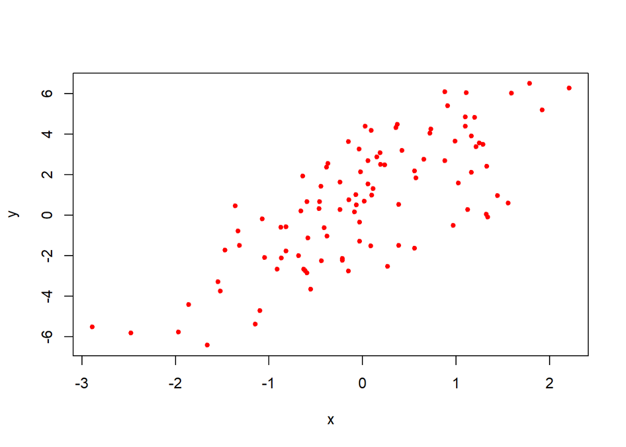

```r
plot(x,y,cex=1,pch=20,col="red")
```

- What if x is binary?

```r
set.seed(10)
x <-rbinom(100,1,0.5)
e <-rnorm(100,0,2)
y <-0.5 + 2*x + e
summary(y)
```

```
   Min. 1st Qu.  Median    Mean 3rd Qu.    Max.
-3.4936 -0.1409  1.5767  1.4322  2.8397  6.9410
```

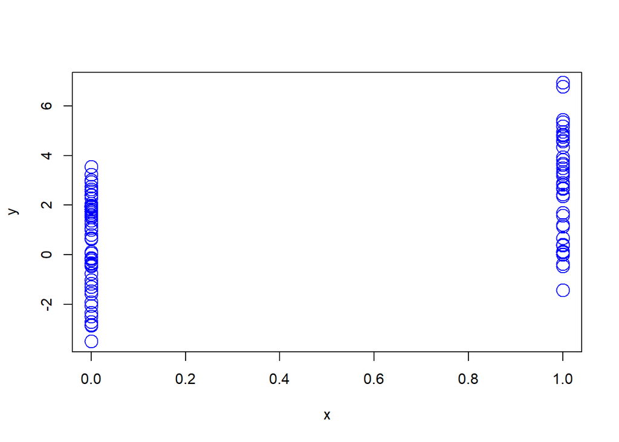

```r
plot(x,y,cex=2,col="blue")
```

- x binary: may be x represents gender. Here we use the binomial distribution. rbinom(100,1,0.5) means n=1 and p=0.5.

## Generating Random Numbers from a generalized linear model

- Suppose we want to simulate from a poisson model where Y~Poisson(U), logU = Bo + B1x and Bo=0.5 and B1=0.3.
- We need to use the rpois function for this.

```r
set.seed(1)
x <-rnorm(100)
log.U <-0.5 + 0.3*x
y <-rpois(100,exp(log.U))
summary(y)
```

```
   Min. 1st Qu.  Median    Mean 3rd Qu.    Max.
   0.00    1.00    1.00    1.55    2.00    6.00
```

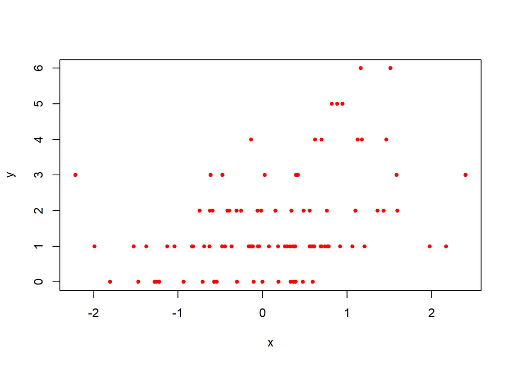

```r
plot(x,y,cex=1,pch=20,col="red")
```

- In this instance, the error is not going to be normal. It is going to be poisson. There is a linear relationship between x and y. This looks like poisson data.

## Simulation - Random Sampling

- The sample function draws randomly from a specified set of (scalar) objects allowing you to sample from arbitrary distribution.

```r
set.seed(1)
sample(1:10,4)
```

```
[1] 3 4 5 7
```

```r
sample(letters,5)
```

```
[1] "f" "w" "y" "p" "n"
```

```r
sample(1:10) # permutation
```

```
 [1]  1  2  9  5  3  4  8  6  7 10
```

```r
sample(1:10,replace=TRUE) # sample with replacement
```

```
 [1]  8 10  3  7  2  3  4  1  4  9
```

## Simulation

### Summary

- Drawing samples from specific probability distributions can be done with r * function.
- Standard distributions are built in: Normal, Poisson, Binomial, Exponential, Gamma etc.
- The sample function can be used to draw random samples from arbitrary vectors.
- Setting the random number generator seed via set.seed is critical for reproducibility.